# Администрирование сетевых подсистем

Настройка файловых служб Samba

Сейдалиев Тагиетдин Ровшенович

Российский университет дружбы народов, Москва, Россия

08 декабря 2025

# Цель работы

## Основная цель

Получить навыки настройки доступа групп пользователей  
к общим ресурсам по протоколу SMB (Samba).

# Настройка сервера Samba

## Установка пакетов

- Установлены компоненты *samba*, *samba-client*, *cifs-utils*
- Подготовка окружения сервера для работы файлового сервиса

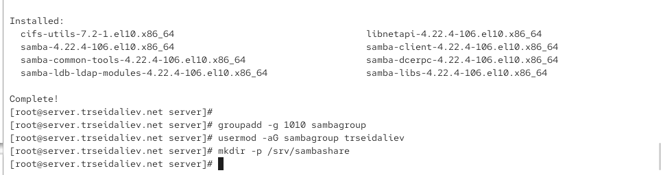

Установка пакетов Samba

## Пользователи и группы

- Создана группа **sambagroup (GID 1010)**
- Пользователь **trseidaliev** добавлен в группу
- Создан каталог общего доступа: `/srv/sambashare`

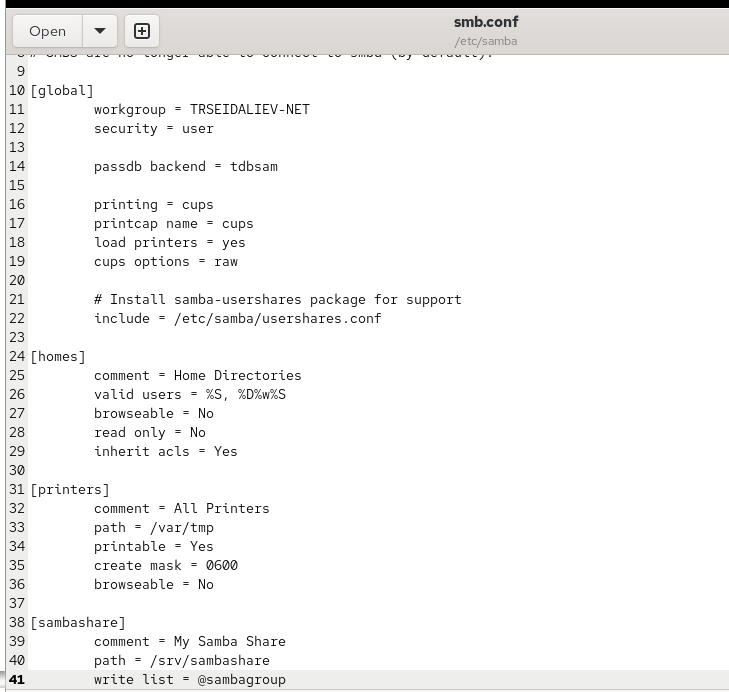

smb.conf

## Проверка работоспособности SMB

- Служба **smb** запущена и добавлена в автозагрузку
- Проверка статуса показала, что сервис активен

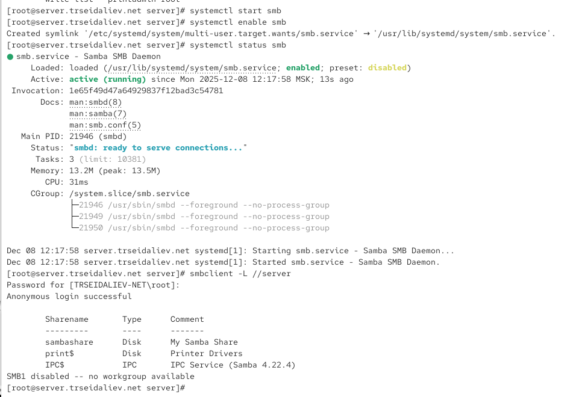

Статус службы SMB

## Разрешение Samba в firewalld

- Просмотр конфигурации samba.xml
- Разрешены сервисы Samba в firewalld
- Выполнен reload firewall

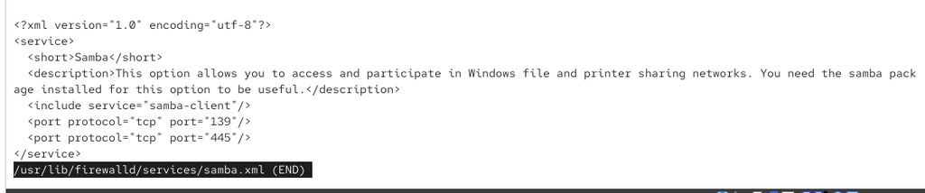

Профиль Samba